# Projet AED : Productivité horaire du travail VS Nombre d’heures travaillées

LUNETTE Malcom, HUANG Luxuan

# 1 - Introduction

#### Contexte et Motivation

Intuitivement, nous pourrions penser que travailler plus d’heures rend un pays plus productif. Pourtant, nous constatons une relation paradoxale : en 2019, les données observées nous montrent que les Français ont travaillé (en moyenne, par personne) 1504 heures pour produire 80$ par heures travaillées, tandis que les Allemands, au même moment, ont travaillé seulement 1372 heures pour produire 81$ par heures travaillées : pour une productivité équivalente, les Allemands travaillent 9% d’heures en moins. Ce constat nous a fait soulever la question suivante : quelle relation existe-t-il entre volume de travail et productivité horaire ?

#### Définition

En économie, la productivité est définie par le rapport entre la production (*output*) et les facteurs utilisés lors du processus de production (*input*). Parmi ces facteurs de production, on compte le capital (les biens durables utilisés dans la production), et le travail (l’effort humain consacré à la production). C’est le travail qui nous intéresse ici, en particulier la productivité horaire du travail, définie comme suit :

$Productivité\ horaire\ du\ travail\ = \dfrac{PIB\ total}{Nombre\ total\ d'heures\ travaillées}$

Cette métrique est exprimée en dollars par heure ($/h), et nous permet de comparer la productivité des pays entre eux, indépendamment de la taille de leur population, et de leur économie.

#### Données

Notre analyse mobilise les données extraites du site Our World in Data, produites par Penn World Table 11.0, couvrant 130 pays entre 1950 et 2023. Les variables retenues sont :

- **Productivité horaire** : PIB par heures travaillées, exprimé en dollars internationaux 2021 en parité de pouvoir d’achat (PPA), permettant la comparabilité internationale,
- **Heures travaillées** : Moyenne annuelle par travailleur actif,
- **Population** : Utilisée comme pondération dans les visualisations.

#### Limitations identifiées

Les données africaines ne débutent qu’en 2001, contre 1950 pour les autres continents. Dans un souci méthodologique, nous avons choisi de concentrer l’analyse comparative sur la période 2001-2023, permettant d’inclure l’Afrique tout en conservant une profondeur historique suffisante.

## Tableau : échantillon partiel des pays analysés pour l’année 2019

Données brutes pour 2019 (productivité en $/h ; heures travaillées en h/année/travailleur)

| country | year | productivity | workhour | population | continent |
| --- | --- | --- | --- | --- | --- |
| Australia | 2019 | 71.465910 | 1632.29 | 25482714 | Oceania |
| Brazil | 2019 | 19.152273 | 1972.91 | 207455459 | Americas |
| Canada | 2019 | 60.960705 | 1748.33 | 37782934 | Americas |
| China | 2019 | 14.174832 | 2357.20 | 1423520357 | Asia |
| Colombia | 2019 | 15.812911 | 2382.61 | 49907987 | Americas |
| Democratic Republic of Congo | 2019 | 1.805877 | 1824.64 | 92947450 | Africa |
| France | 2019 | 80.233720 | 1504.38 | 65729460 | Europe |
| Germany | 2019 | 81.118675 | 1372.04 | 83559184 | Europe |
| India | 2019 | 7.462654 | 2605.39 | 1389030307 | Asia |
| Ireland | 2019 | 141.343890 | 1760.02 | 4933493 | Europe |
| Japan | 2019 | 48.807823 | 1687.80 | 126699421 | Asia |
| Mexico | 2019 | 28.918913 | 1639.34 | 125762978 | Americas |
| Nigeria | 2019 | 8.120003 | 1994.80 | 209485637 | Africa |
| Russia | 2019 | 33.838017 | 2062.40 | 146533063 | Europe |
| Singapore | 2019 | 62.331562 | 2330.77 | 5669562 | Asia |
| South Korea | 2019 | 49.544704 | 1963.22 | 51767844 | Asia |
| United States | 2019 | 77.742090 | 1796.65 | 337790069 | Americas |

# 2 - Résultats

## Statistiques descriptives

**Moyennes et corrélations par continent (2001-2023) :**

| Continent | Nb de pays | Productivité moyenne ($/h) | Nombre d’heures moyen/an | Corrélation |
| --- | --- | --- | --- | --- |
| Oceania | 2 | 55.9 | 1696 | -0.96 |
| Europe | 38 | 50.1 | 1729 | -0.75 |
| Asia | 40 | 27.7 | 2162 | -0.02 |
| Americas | 18 | 25.4 | 1936 | -0.53 |
| Africa | 32 | 9.2 | 2022 | 0.42 |

#### Analyse des résultats statistiques

Les corrélations sont calculées en agrégeant l’ensemble des observations (pays × années) de chaque continent sur 2001-2023. Elles reflètent à la fois les différences structurelles entre pays et les évolutions temporelles, sans distinguer les deux effets. Le choix de considérer les *données poolées*[^1] a été fait pour observer les tendances générales des continents.

**Europe/Océanie** affichent une forte corrélation négative (-0.75, -0.96), suivies de près par l’**Amérique** (-0.53) : les pays travaillant moins d’heures tendent à afficher une productivité plus élevée.

**L’Asie** présente une corrélation quasi-nulle (-0.02), reflétant une grande hétérogénéité : on observe conjointement des pays travaillant beaucoup d’heures et produisant peu, et des pays avec une grande productivité dont le temps de travail est plus faible. Par exemple, en 2019, Singapour (2330h, 62$/h) et le Japon (1687h, 49$/h) coexistent avec l’Inde (2605h, 7$/h) et la Chine (2357h, 14$/h). Cette hétérogénéité annule tout pattern général.

**L’Afrique** montre une corrélation positive (+0.42) : l’accroîssement du volume horaire s’associe à des gains de productivité, pattern inverse de celui observé en Europe, en Océanie et en Amérique.

Ces trois groupes présentent ainsi des tendances différentes, qui s’expriment visuellement par le graphique suivant.

## Graphique statique : 2019, dernière année stable avant le Covid

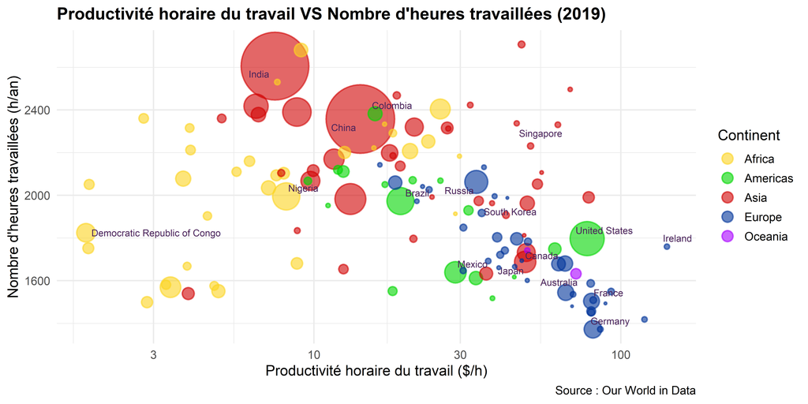

#### Analyse par continent

Le graphique confirme visuellement les trois patterns identifiés statistiquement.

Nous utilisons l’échelle logarithmique pour exprimer la productivité afin de tenir compte de la forte dispersion des valeurs entre les pays. En effet, la productivité varie de 1.8$/h pour la République Démocratique du Congo, à 141.3$/h pour l’Irlande, soit un rapport d’environ 1:78. Visuellement, cette échelle évite de compresser les pays à faible productivité, nous permettant une meilleure comparaison.

**L’Europe, et l’Océanie** se concentrent dans la zone haute productivité/faibles nombre d’heures travaillées (50-120$/h, 1400-1800h/an). Les pays les plus peuplés présentent tous ce schéma, à l’exception de la Russie (qui dépasse les 2000h/an). **Les Amériques** présentent une dispersion intermédiaire : les États-Unis (78$/h, 1797h) et le Canada (61$/h, 1748h) se rapprochent du modèle européen, tandis que les pays d’Amérique latine (Mexique, Brésil, Colombie) combinent productivité moyenne (15-30$/h) et volumes plus élevés (1600-2400h).

**L’Asie** se répartit sur un large spectre : les géants démographiques (Chine, Inde) occupent la zone haut volume horaire/faible productivité (2200-2600h, 7-15$/h), tandis que Singapour, Japon et Corée du Sud se rapprochent du modèle européen.

## Animation

[interactive chart not shown]

#### Analyse animation 2001-2023

*Convergence limitée :* Malgré les gains de productivité asiatiques et africains, les écarts relatifs entre continents demeurent stables. L’Europe conserve son avance (50-60$/h en moyenne) tandis que l’Afrique progresse lentement : la grande majorité des pays gardent une productivité inférieure à 10$/h entre 2005 et 2023.

## Conclusion

L’analyse de 130 pays sur 2001-2023 confirme une relation entre volume horaire et productivité, mais révèle des dynamiques régionales contrastées. L’Europe illustre un modèle d’une haute efficience, l’Afrique suit un schéma inverse, et l’Asie présente une grande hétérogénéité, qui annule toute corrélation globale.

Ces résultats suggèrent que le volume de travail seul ne détermine pas mécaniquement la productivité : nous devrions considérer d’autres éléments, comme des facteurs structurels (par exemple le capital, l’éducation, les différents secteurs d’activité) pour exprimer la productivité plus précisément.

# Appendince : Code complet

```r
# =============================================================================
# 0. Package initialization and data download
# =============================================================================
packages <- c("dplyr", "ggplot2", "plotly", "countrycode", "ggrepel")

for (pkg in packages) {
  if (!requireNamespace(pkg, quietly = TRUE)) {
    install.packages(pkg, dependencies = TRUE)
  }
  library(pkg, character.only = TRUE)
}

# Download and make a clean dataframe from ourworldindata's productivity data
url_productivity <- "https://ourworldindata.org/grapher/labor-productivity-per-hour-pennworldtable.csv?v=1&csvType=full&useColumnShortNames=true"
productivity <-  read.csv(url_productivity) |>
  dplyr::select(entity, year,productivity) |>
  dplyr::rename(country = entity)

# Same with working hours data
url_workhour <- "https://ourworldindata.org/grapher/annual-working-hours-per-worker.csv?v=1&csvType=full&useColumnShortNames=true"
workhour <-read.csv(url_workhour) |>
  dplyr::select(entity, year,working_hours_omm) |>
  dplyr::rename(country = entity, workhour = working_hours_omm)

# Same with population data
url_population <- "https://ourworldindata.org/grapher/population.csv?v=1&csvType=full&useColumnShortNames=true"
population <-  read.csv(url_population) |>
  dplyr::select(entity, year,population_historical) |>
  dplyr::rename(country = entity, population = population_historical)
# Now we have three datasets

# =============================================================================
# 1. Data preparation
# =============================================================================

# We merge the productivity and working hours dataframes into one with inner_join(). Inner means empty (NA) observations/rows are discarded
productivity_workhour <- dplyr::inner_join(x=productivity, y=workhour, by=dplyr::join_by(country, year))
# Now we have a dataset with the following columns/variables: country, year, productivity, working_hours_omm

# We merge the (productivity+working hours) and population dataframes. Here also, inner_join() to remove observations with empty values.
# We also use the countrycode library to add a column with continent of each observation (to make the figure more beautiful)
df <- dplyr::inner_join(x=productivity_workhour, y=population,
                        by=dplyr::join_by(country, year)) |>
  dplyr::mutate(
    continent = countrycode(country, origin = "country.name", destination = "continent")
  ) |>
  dplyr::filter(!is.na(continent)) |>
  dplyr::group_by(year) |>
  dplyr::filter(n_distinct(continent) == 5) |>    # We only keep years where all 5 continents are represented
  dplyr::ungroup() |>
  dplyr::arrange(country, year)

# Tableau : échantillon partiel des pays analysés pour l'année 2019
knitr::kable(filter(df, year == 2019, country %in% c(
    "China", "Japan", "Singapore",
    "United States", "Mexico",
    "India", "Democratic Republic of Congo", "Nigeria",
    "Brazil", "France", "Germany", "Australia", "Ireland", "Russia",
    "Colombia", "Canada", "South Korea"
    )) [, ], caption = 'Données brutes pour 2019 (productivité en $/h ; heures travaillées en h/année/travailleur)')
#Moyennes et corrélations par continent (2001-2023)
knitr::kable(stats_full <- df |>
  group_by(continent) |>
  summarise(
    nb_pays = n_distinct(country),
    prod_moy = round(mean(productivity), 1),
    heures_moy = round(mean(workhour), 0),
    correlation = round(cor(workhour, productivity), 2),
    .groups = "drop"
  ) |>
  arrange(desc(prod_moy)),
  col.names = c("Continent","Nb de pays","Productivité moyenne ($/h)","Nombre d'heures moyen/an","Corrélation")
)


# =============================================================================
# 2. Creation of static plots with ggplot
# =============================================================================

figure_static <- df |>
  filter(year == 2019) |>
  arrange(desc(population)) |>
  ggplot(aes(x = productivity,
             y = workhour,
             color = continent,
             size = population,
             label = country)) +
  geom_point(alpha = 0.6, stroke = 1.0) +
  geom_text_repel(
    data = ~ filter (.x, country %in% c(
      "China", "Japan", "Singapore",
      "United States", "Mexico",
      "India", "Democratic Republic of Congo","Nigeria",
      "Brazil", "France", "Germany","Australia", "Ireland", "Russia",
      "Colombia", "Canada", "South Korea")),  # We only display part of the countries
    aes(label = country),
    size = 3,
    max.overlaps = 20,
    color = "#4A235A"
    )+
  scale_color_manual(values = c(
    "Africa"   = "#fcd421",
    "Americas" = "#00d600",
    "Asia"     = "#d10202",
    "Europe"   = "#003399",
    "Oceania"  = "#A800FF"
  )) +
  scale_size_area(
    max_size = 28,
    labels = scales::label_number(scale = 1/1e6, suffix = "B")
  ) +
  scale_x_log10() +
  theme_minimal(base_size = 13) +
  theme(
    legend.position = "right",
    plot.title = element_text(face = "bold", size = 15)
  ) +
  guides(
    color = guide_legend(title = "Continent", override.aes = list(size = 4)),
    size  = "none"
  ) +
  labs(title = "Productivité horaire du travail VS Nombre d'heures travaillées (2019)",
       x = "Productivité horaire du travail ($/h)",
       y = "Nombre d'heures travaillées (h/an)",
       caption = "Source : Our World in Data")
figure_static


# =============================================================================
# 3. Creation of animated plots with plotly
# =============================================================================

continent_colors <- c(
  "Africa"   = "#fcd421",
  "Americas" = "#00d600",
  "Asia"     = "#d10202",
  "Europe"   = "#003399",
  "Oceania"  = "#A800FF"
)
pop_min <- min(df$population)
pop_max <- max(df$population)

countries_to_label <- c( "China", "Japan", "Singapore",
                          "United States", "Mexico",
                          "India", "Democratic Republic of Congo","Nigeria",
                          "Brazil", "France", "Germany","Australia", "Ireland", "Russia",
                         "Colombia", "Canada", "South Korea")

df_sorted <- df |>
  arrange(year, desc(population)) |>
  mutate(
    bubble_size = 2 + (population - pop_min) / (pop_max - pop_min) * 56,
    label       = ifelse(country %in% countries_to_label, country, NA))

figure <- plot_ly(
   data         = df_sorted,
   x            = ~productivity,
   y            = ~workhour,
   size         = ~bubble_size,
   type         = "scatter",
   mode         = "markers+text",
   color        = ~continent,
   colors       = continent_colors,
   frame        = ~year,
   ids          = ~country,
   text         = ~label,
   textposition = "center",
   textfont     = list(color = "#4A235A", size = 10),
   customdata   = ~paste0(
     "Country: ",          country,
     "<br>Productivity: ", round(productivity, 1), " usd/hr",
     "<br>Workhour: ",     round(workhour, 1),     " hrs/year",
     "<br>Population: ",   round(population / 1e6, 1), "M"
   ),
   hovertemplate = "%{customdata}<extra></extra>",
   marker = list(
     opacity  = 0.6,
     sizemode = "diameter",
     sizeref  = 1
   )
   ) |>

  layout(
    title  = list(text = "<b>Productivité horaire du travail VS Nombre d'heures travaillées, 2001-2023</b>",
                  font = list(size = 15)),
    xaxis  = list(title = "Productivité horaire du travail ($/h)", type = "log"),
    yaxis  = list(title = "Nombre d'heures travaillées(h/an)"),
    legend = list(title = list(text = "Continent")),
    paper_bgcolor = "white",
    plot_bgcolor  = "#f9f9f9"
  ) |>
  animation_opts(frame = 800, easing = "linear", redraw = FALSE) |>
  animation_slider(currentvalue = list(prefix = "Year: ", font = list(size = 13))) |>
  animation_button(x = 0, xanchor = "right", y = 0, yanchor = "top")

figure
```

## Footnotes

[^1]: **Données poolées :** Données agrégées pour être analysées ensemble. Ici, le coefficient de corrélation est calculé pour chaque continent à partir de l’ensemble des données relatives au continent considéré. On y agrège donc, par continent, les données (productivité et heures travaillées) de tous les pays et de toutes les années confondus.